# Inteligencia Artificial Generativa (AI Gen)

Universidad Austral

Clase 1: Bienvenidos / Introducción

Autor: Paulo Veiga, Claudio Righetti y Marco Sorondo  
Última modificación: Agosto de 2026

01Bienvenidos 02¿Por qué esta materia? 03Logística 04Fundamento de AI 05Taxinomia de Problemas 06Modelos Fundacionales 07Datos 08Ecosistema Actual 09Cierre y anexo

01

Bienvenidos

Bienvenidos

Inteligencia General Generativa

Clase 1: Bienvenida y Logistica · Autor: Paulo Gustavo Veiga, Marco Sorondo · Ultima Modification: Aug, 2026

Bienvenidos

## Bienvenidos!

- ¿Por qué eligieron esta materia?
- ¿Qué esperan llevarse de la cursada?

[figure not shown]

Bienvenidos

## Que es Inteligencia Artificial Generativa ?

Bienvenidos! Este curso explorará los fundamentos, aplicaciones y desafíos de la Inteligencia Artificial Generativa, un campo revolucionario que está transformando nuestra interacción con la tecnología.

- A lo largo de este cuatrimestre, analizaremos los conceptos básicos de la GenAI, los modelos de lenguaje generativos, la visión artificial, y los aspectos éticos relacionados con esta tecnología emergente.

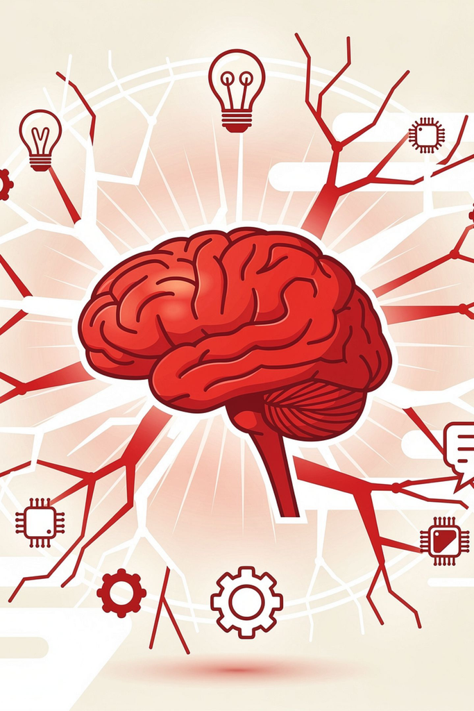

Bienvenidos

## Qué esperamos que se lleven

Una materia para entender cómo funcionan los modelos y aprender a construir con ellos con criterio de Ingeniería de Software.

### Meternos en los modelos

Van a poder explicar qué hacen los transformers, cómo intervienen los datos, el entrenamiento, la inferencia y la evaluación; no sólo usar una interfaz de chat.

### Práctica hands-on

Las clases combinan teoría y práctica: notebooks, repositorios, prompts, herramientas y casos concretos para experimentar, implementar, probar y documentar.

### Criterio de ingeniería

El objetivo es usar IA generativa sin delegar el juicio técnico: evaluar salidas, reconocer límites y diseñar flujos con trazabilidad, seguridad y control humano.

Bienvenidos

## Antes que nada…

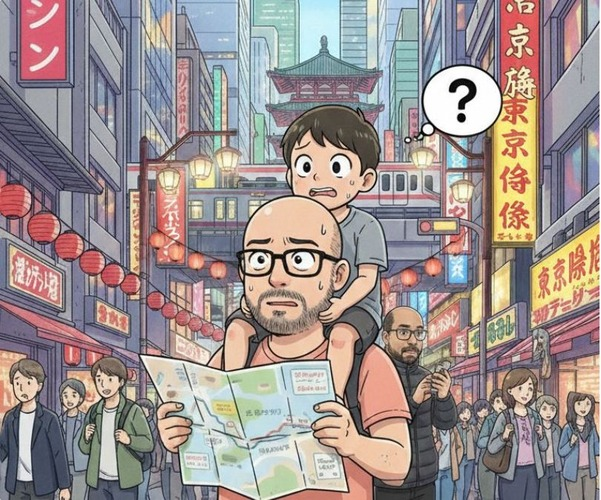

#### Paulo Veiga

Email: pveiga@austral.edu.ar

[figure not shown]

#### Marco Sanchez Sorondo

Email: msanchezSorondo@austral.edu.ar

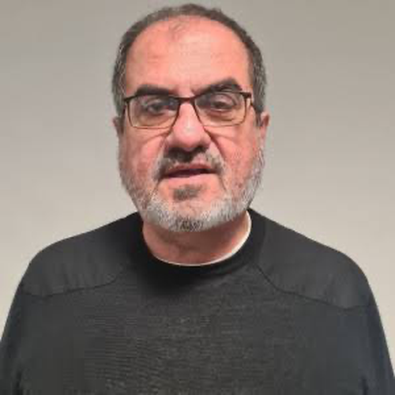

#### Claudio Righetti

Docente

Bienvenidos

## Ahora cuéntennos ustedes

Cuatro preguntas para responder en vivo desde el celular.

1

¿Por qué eligieron esta materia?

2

¿Qué esperan llevarse de la cursada?

3

¿Cuánto usan hoy herramientas de IA generativa para estudiar o programar?

4

¿Qué es lo que más les preocupa de la IA en su futuro profesional?

Entrar en https://app.sli.do/event/s7Ccr6C4awbUzRW1RpH19c

01Bienvenidos 02¿Por qué esta materia? 03Logística 04Fundamento de AI 05Taxinomia de Problemas 06Modelos Fundacionales 07Datos 08Ecosistema Actual 09Cierre y anexo

02

¿Por qué esta materia?

¿Por qué esta materia?

## ¿Por qué esto es relevante para tu carrera?

La IA generativa cambia la forma de analizar requisitos, escribir código, crear pruebas, mantener documentación y operar sistemas.

### El mercado ya la incorpora

Las organizaciones suman asistentes de IA a sus flujos de desarrollo. Quienes entiendan sus límites y sepan evaluarlos pueden aportar criterio técnico desde el primer día.

### Ingeniería de Software es un área de alto impacto

Copilotos de código, revisión de cambios, generación de pruebas, búsqueda sobre repositorios y soporte a incidentes ya afectan tareas reales de los equipos.

### Diferenciación profesional

Un ingeniero que entiende IA puede liderar proyectos, definir controles de calidad y conversar con producto, seguridad, datos y negocio.

### Impacto en todas las ciencias

Hoy desarrolla cualquiera. Un ingeniero químico arma su script de simulación y un contador automatiza un cierre contable, con ChatGPT, Claude, Gemini o Copilot. El ingeniero de software sabe exigir evidencia, pruebas y responsabilidad antes de que ese código llegue a producción.

¿Por qué esta materia?

## El impacto de GenAI en la economía

### Impulso histórico a la productividad

Automatización de tareas cognitivas y repetitivas, actuando como un "copiloto" para los trabajadores.

### Creación de valor masivo

Se estima que la GenAI podría añadir entre 2,6 y 4,4 billones de dólares anuales a la economía global (equivalente al PIB de un país como Reino Unido).

### Transformación de funciones corporativas

Impacto directo en operaciones, marketing, ventas, atención al cliente y desarrollo de software.

### Nuevas industrias

Aparición de modelos de negocio inéditos y roles especializados (ej. ingeniería de prompts, auditoría algorítmica).

Fuente: McKinsey & Company — [The economic potential of generative AI: the next productivity frontier](https://www.mckinsey.com/capabilities/mckinsey-digital/our-insights/the-economic-potential-of-generative-ai-the-next-productivity-frontier)

¿Por qué esta materia?

## Impacto por industria y funciones

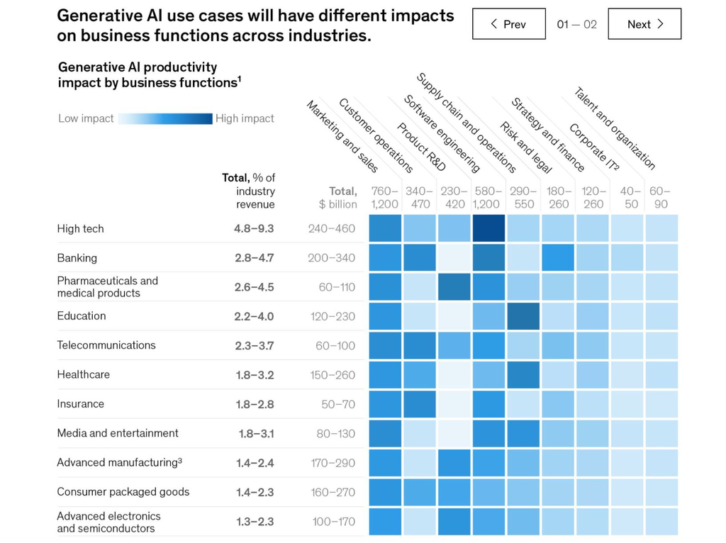

¿Por qué esta materia?

## Transformación en Ingeniería de Software

### Aceleración del desarrollo de software

Los modelos pueden asistir en lectura de repositorios, generación de código, explicación de errores y creación de pruebas. El equipo conserva la responsabilidad de revisar, integrar y desplegar.

### Productos más adaptables

La IA permite explorar interfaces, personalizar flujos y analizar grandes volúmenes de feedback, tickets y telemetría. La personalización exige datos autorizados y criterios explícitos.

### Mejora de calidad y seguridad

Los equipos pueden usar IA para detectar patrones de fallas, proponer casos de prueba, resumir incidentes y encontrar documentación relevante. Ninguna sugerencia reemplaza una validación técnica.

### Eficiencia operativa

La automatización de runbooks, soporte y documentación puede devolver tiempo para resolver problemas de mayor valor. Los procesos necesitan registros, permisos y mecanismos de reversión.

### Redefinición de roles y responsabilidades

El equipo se reorganiza alrededor de la revisión. Quien integra código generado responde por él, y la revisión de pares concentra el control sobre la salida del modelo. Aparecen responsabilidades nuevas sobre datos, permisos y trazabilidad.

¿Por qué esta materia?

## Limitaciones de la IA Generativa

### Alucinaciones y respuestas falsas

Los modelos pueden generar código, APIs, librerías o explicaciones incorrectas con tono convincente. Una salida debe pasar por pruebas, revisión y contraste con documentación oficial.

### Sesgos en los datos

Los datos de entrenamiento y los repositorios históricos contienen decisiones, desigualdades y prácticas inseguras. Un modelo puede reproducirlas sin advertirlo.

### Privacidad y protección de datos

Prompts, adjuntos y contexto pueden incluir código propietario, secretos, datos personales o información de clientes. El equipo debe conocer dónde se procesa y retiene cada dato.

### Sesgo de automatización

Un resultado sugerido por una herramienta puede recibir confianza excesiva. La revisión humana necesita criterios y tiempo asignado, no solo una aprobación nominal.

### Acceso desigual

El costo de modelos, cómputo y conectividad condiciona quién puede experimentar, construir y desplegar soluciones.

### Impacto ambiental

Entrenar y operar modelos a gran escala requiere energía, agua e infraestructura. El costo ambiental forma parte de la decisión de arquitectura.

### Degradación de habilidades técnicas

Un uso sin comprensión puede erosionar la capacidad de depurar, diseñar y operar sistemas cuando la herramienta falla o entrega una respuesta errónea.

¿Por qué esta materia?

## El riesgo macroeconómico y el colapso del consumo

### La crisis global de inteligencia 2028

Un escenario hipotético sobre los peligros de una transición demasiado abrupta hacia la IA.

### El “PIB fantasma”

Récord de productividad y ganancias corporativas impulsadas por IA que no circulan en la economía real, porque las máquinas no consumen.

### Desplazamiento del “cuello blanco”

En el escenario, la IA reemplaza a los trabajadores del conocimiento, que representan el 50% del empleo y el 75% del gasto discrecional.

### La espiral deflacionaria

Las empresas despiden, cae el poder adquisitivo y el consumo colapsa. Para bajar costos las empresas invierten más en IA, y el ciclo se refuerza.

Fuente: Citrini Research — [The 2028 Global Intelligence Crisis](https://www.citriniresearch.com/p/2028gic)

01Bienvenidos 02¿Por qué esta materia? 03Logística 04Fundamento de AI 05Taxinomia de Problemas 06Modelos Fundacionales 07Datos 08Ecosistema Actual 09Cierre y anexo

03

Logística

Logística

## Cómo vamos a trabajar

1

Son 14 clases, los miércoles, y cada una mezcla concepto, ejemplo y práctica.

2

Primero discutimos la idea y después la llevamos a notebooks, repositorios y casos concretos.

3

El trabajo es en equipo, con registro de las pruebas y de las decisiones.

4

Cada dos clases hay un entregable práctico.

5

Esperamos presencia y participación activa.

Logística

## Entregables de clase

Forman parte de la evaluación junto con el trabajo final.

1

#### Ritmo

Un entregable cada dos clases, relacionado con los temas vistos.

2

#### Equipo

Se trabaja en equipos de cuatro personas: dos de Ingeniería en Sistemas y dos de Ciencia de Datos.

3

#### Trabajo durante la clase

La mayor parte del trabajo se completa durante la clase.

4

#### Evidencia

Cada equipo debe dejar trazabilidad de decisiones, prompts, código, pruebas y fuentes usadas.

5

#### Entrega obligatoria

Se entrega por el canal que indique la cátedra, con repositorio o artefactos reproducibles cuando corresponda.

Logística

## Trabajo final

Un proyecto propio que aplique conceptos de la materia a un problema de Ingeniería de Software.

1

Se trabaja en equipos de cuatro personas, dos de Ingeniería en Sistemas y dos de Ciencia de Datos.

2

El equipo debe ser el mismo que realizó los trabajos prácticos.

3

La consigna completa se presenta a mitad de cuatrimestre.

4

Se entrega un video breve de demostración que explique el problema, la solución y sus límites.

5

Se entrega el código desplegado o ejecutable, con instrucciones de reproducción.

6

Se entrega la documentación del diseño, los datos, la estrategia de evaluación, los riesgos y las decisiones de seguridad.

Logística

## Evaluación

Cómo se compone la nota final

40%Entregables de clase

60%Trabajo final

Las entregas fuera de término impactan en la nota final.

Logística

## Contenidos de la Materia

Recorrido de la materia

1

#### Módulo 1: Fundamentos de IA, arquitectura de LLM y entrenamiento

Clases 1–4

2

#### Módulo 2: Ingeniería de prompts, RAG y desarrollo asistido por IA

Clases 5–8

3

#### Módulo 3: Generación multimodal, visión e interfaces

Clases 9–12

4

#### Módulo 4: Agentes, evaluación, ética, seguridad y regulación

Logística

PreguntasAbrimos la conversación.

01Bienvenidos 02¿Por qué esta materia? 03Logística 04Fundamento de AI 05Taxinomia de Problemas 06Modelos Fundacionales 07Datos 08Ecosistema Actual 09Cierre y anexo

04

Fundamento de AI

Fundamento de AI

Inteligencia General Generativa

Clase 1: Fundamentos, Modelos y el Ecosistema Actual

Fundamento de AI

## ¿Qué es la Inteligencia Artificial?

De la teoría a la intuición

### Intuición

Un sistema de IA no lleva escrita una regla por cada situación. Aprende patrones a partir de datos y los aplica a casos que nunca vio, con un mecanismo que recuerda al del cerebro humano.

### Un poco más formal

La IA es el diseño de agentes racionales: sistemas que perciben su entorno y toman acciones para maximizar **sus posibilidades de éxito en un objetivo dado**. Resolver problemas complejos con matemáticas a gran escala, en lugar de crear humanos sintéticos.

La IA no es magia: es estadística, álgebra lineal y grandes cantidades de datos bien organizados.

**Fuente**: Russell & Norvig, "Artificial Intelligence: A Modern Approach"

Fundamento de AI

## Una Breve Historia (Parte 1)

De Turing al primer invierno — 1948 a 1997

#### 1948

**La Teoría de la Información (Claude Shannon)** — Shannon publica "A Mathematical Theory of Communication". Define conceptos como bit, entropía y canal de comunicación, sentando las bases matemáticas para el procesamiento de datos.

#### 1950

**El test de Turing** — Alan Turing propone la pregunta "¿Pueden pensar las máquinas?" y la reemplaza por un experimento observable, el juego de la imitación. Nace el marco conceptual de la IA.

#### 1956

**Nacimiento oficial** — Conferencia de Dartmouth. John McCarthy acuña el término "Inteligencia Artificial". Comienza la primera era de optimismo.

#### 1958

**El Perceptrón (Frank Rosenblatt)** — Rosenblatt crea la primera red neuronal artificial capaz de aprender. Minsky y Papert demostrarían en 1969 sus limitaciones, desencadenando el primer "invierno de la IA".

#### 1980-90s

**Sistemas expertos e inviernos** — Auge y caída de los sistemas basados en reglas. Los "inviernos de la IA" frenan la inversión y la investigación.

#### 1986

**Backpropagation revoluciona el aprendizaje** — Rumelhart, Hinton y Williams popularizan el algoritmo de retropropagación del error, permitiendo entrenar redes neuronales multicapa.

#### 1997

**Deep Blue vence a Kasparov** — La supercomputadora de IBM derrota al campeón mundial Garry Kasparov por 3½-2½. Primera vez que una máquina gana un match completo contra el mejor ajedrecista del mundo. No hay aprendizaje: es fuerza bruta (200M de posiciones por segundo) más reglas escritas por humanos.

Fundamento de AI

## Redes Neuronales — Estructura y Celda Básica

De la neurona biológica al perceptrón artificial

- **Red neuronal simple**: Anatomía de una neurona artificial.
- **Entradas (x₁, x₂, ..., xₙ)**: Señales de entrada — datos crudos o salidas de neuronas anteriores.
- **Pesos (w₁, w₂, ..., wₙ)**: Cada entrada se multiplica por un peso. El modelo aprende ajustando estos valores durante el entrenamiento.
- **Suma ponderada + bias**: z = w₁x₁ + w₂x₂ + ... + wₙxₙ + b El bias permite desplazar la función de activación.
- **Función de activación f(z)**: Introduce no-linealidad. Ejemplos: ReLU, Sigmoid, Tanh. Determina si la neurona "se activa" y con qué intensidad.
- **Salida**: Output: ŷ = f(z)

[figure not shown]

Fundamento de AI

## Una Breve Historia (Parte 2)

Del deep learning a la era generativa — 2011 a 2026

#### 2011

**Watson gana en Jeopardy!** — IBM Watson derrota a los mejores campeones humanos del concurso de preguntas. Demuestra comprensión del lenguaje natural a gran escala.

#### 2012

**La revolución del deep learning** — AlexNet gana ImageNet con una ventaja histórica. Las redes neuronales profundas y las GPUs cambian todo: el ingeniero de visión ya no escribe los detectores a mano, los aprende la red.

#### 2016

**AlphaGo vence a Lee Sedol** — Google DeepMind derrota al campeón mundial de Go, un juego con más combinaciones posibles que átomos en el universo. Considerado imposible para la IA hasta ese momento. Toma decisiones estratégicas en un espacio de búsqueda enorme.

#### 2017

**Atención es todo** — Google publica "Attention Is All You Need". Nace la arquitectura Transformer, base de todos los modelos modernos.

#### 2020s

**Era generativa** — GPT-3, ChatGPT, Gemini, Claude. Los Foundation Models democratizan el acceso a capacidades de IA sin precedentes.

#### 2022

**ChatGPT rompe internet** — OpenAI lanza ChatGPT. Alcanza 100 millones de usuarios en 2 meses, el producto de mayor crecimiento en la historia.

#### 2025

**La IA se abarata y empieza a actuar** — DeepSeek R1 derrumba el costo del razonamiento y borra ~US$590.000M de valor de Nvidia en un día; en paralelo, los agentes pasan de demo a producción y MCP se consolida como estándar de conexión.

#### 2026

**La IA encuentra lo que décadas de revisión humana no vieron** — Anthropic reporta más de 10.000 vulnerabilidades halladas por Claude Mythos en el primer mes de Glasswing: 2.000 en Cloudflare y 271 de Firefox ya corregidas. El caso más citado, una ejecución remota de 17 años en el NFS de FreeBSD explotada sin intervención humana, circula sin CVE ni aviso de seguridad y el propio foro de FreeBSD lo discute.

Fundamento de AI

## Move 37

Segunda partida del match entre AlphaGo y Lee Sedol. Seúl, marzo de 2016. En la jugada 37 AlphaGo apoya una piedra en la quinta línea, lejos de donde se estaba jugando. Los comentaristas la dieron por error. Lee Sedol se levantó de la mesa y tardó más de diez minutos en responder. AlphaGo ganó esa partida y después el match por 4-1.

**Una jugada que ningún humano habría elegido.** El sistema estimó que un jugador humano la jugaría una vez cada diez mil. La eligió igual, porque su evaluación de la posición venía de millones de partidas contra sí mismo y no solo del repertorio humano con el que había empezado a entrenar.

El aprendizaje por refuerzo con self-play generó conocimiento estratégico que la comunidad humana no tenía después de 2.500 años de juego.

**Ver en clase**: "Move 37!! Lee Sedol vs AlphaGo Match 2" (https://www.youtube.com/watch?v=JNrXgpSEEIE)

01Bienvenidos 02¿Por qué esta materia? 03Logística 04Fundamento de AI 05Taxinomia de Problemas 06Modelos Fundacionales 07Datos 08Ecosistema Actual 09Cierre y anexo

05

Taxinomia de Problemas

Taxinomia de Problemas

## ¿Qué tipos de problemas resuelve la IA?

### Predicción

Aprender X → Y a partir de datos etiquetados. Incluye clasificación y regresión.

### Percepción

Extraer estructura de señales sensoriales: imagen, audio, video.

### Representación

Aprender embeddings y espacios latentes que capturan relaciones entre datos.

### Decisión Secuencial

Maximizar recompensa acumulada. Formalizado como Reinforcement Learning.

### Búsqueda / Planificación

Encontrar la mejor secuencia de acciones en un espacio de estados.

### Razonamiento Simbólico

Manipular símbolos y reglas IF–THEN para derivar conclusiones lógicas.

### Generación

Producir nuevas muestras coherentes: texto, imagen, audio, código. Infinita cantidad de outputs.

Un auto autónomo combina percepción + decisión secuencial + planificación

Taxinomia de Problemas

## Predicción

Aprender una función X → Y a partir de datos etiquetados.

[figure not shown]

Taxinomia de Problemas

## Ejemplos de problemas predictivos

### Clasificación binaria

Spam/no spam · fraude/legítimo · incidente crítico/no crítico

### Clasificación multiclase

Tipo de ticket · categoría de error · prioridad de soporte

### Regresión

Esfuerzo estimado · demanda de infraestructura · tiempo de resolución

### Series temporales

Ventas · uso de recursos · tráfico · volumen de alertas

**Hito**: En 2012, AlexNet (Krizhevsky et al.) ganó ImageNet con 15,3% de error top-5 contra 26,2% del segundo, usando predicción sobre imágenes. Marcó el inicio de la era del deep learning.

Taxinomia de Problemas

## Percepción

Extraer estructura significativa de señales sensoriales.

[figure not shown]

Taxinomia de Problemas

## Ejemplos de problemas de percepción

### Clasificación de imágenes

Qué hay en esta imagen: una captura de pantalla, una foto, un documento escaneado.

### Detección de objetos

Dónde están los elementos y qué son: controles de interfaz, defectos, matrículas.

### Segmentación semántica

Etiquetar cada píxel según su clase.

### Reconocimiento de voz

Audio a texto (ASR) para transcripción, comandos y subtitulado.

### Análisis de video

Detección de eventos y seguimiento de objetos a lo largo de los frames.

### Aplicaciones en software

Procesamiento de facturas y formularios · OCR · accesibilidad · moderación de contenido · análisis de capturas de interfaz · extracción de información de documentos

**Hito**: En 2015, ResNet (Microsoft) superó la precisión humana en reconocimiento de imágenes con un error del 3.57% en ImageNet, por debajo del 5% humano.

Taxinomia de Problemas

## Representación

Aprender estructuras internas que capturan relaciones entre datos.

[figure not shown]

Taxinomia de Problemas

## Ejemplos de problemas de representación

### Embeddings de texto

Palabras, frases, fragmentos de código, documentos y tickets convertidos en vectores de significado.

### Búsqueda semántica

Recuperar documentación y decisiones pasadas por significado, aunque las palabras no coincidan.

### Recomendación

Usuarios, productos, librerías, componentes y expertos ubicados en el mismo espacio vectorial.

### Detección de anomalías

Puntos alejados de la región normal del espacio.

### Clustering

Agrupar datos similares sin etiquetas previas.

**Hito**: En 2013, Word2Vec (Google) mostró que los embeddings capturan relaciones semánticas: Rey − Hombre + Mujer ≈ Reina. Cambió el procesamiento del lenguaje natural.

Taxinomia de Problemas

## Decisión Secuencial

Maximizar recompensa acumulada a través de acciones en el tiempo.

Taxinomia de Problemas

## Ejemplos de problemas de decisión secuencial

### Juegos

Go · ajedrez · Atari · StarCraft

### Robótica

Control de movimiento y manipulación de objetos.

### Trading algorítmico

Estrategias de inversión adaptativas bajo incertidumbre y restricciones.

### Optimización de redes

Tráfico, data centers, balanceo de carga y ajuste de capacidad.

### RLHF

Alinear LLMs con preferencias humanas.

**Riesgo central**: Una recompensa mal definida induce comportamientos útiles para la métrica y dañinos para el objetivo real.

**Hito**: En 2016, AlphaGo (DeepMind) venció a Lee Sedol 4-1 en Go, un juego con más combinaciones que átomos en el universo. En 2017, AlphaZero aprendió ajedrez, Go y shogi desde cero en menos de 24 horas.

Taxinomia de Problemas

## Búsqueda / Planificación

Encontrar la mejor secuencia de acciones en un espacio de estados.

[figure not shown]

Taxinomia de Problemas

## Ejemplos de problemas de búsqueda y planificación

### Logística

Ruta óptima para flotas de reparto (VRP).

### Manufactura

Secuenciación de tareas en producción.

### Planificación

Asignación de recursos con restricciones.

### Planificación de software

Resolución de dependencias · orden de pruebas · orquestación de runbooks · asignación de recursos en la nube.

### Robótica

Trayectorias en espacios físicos.

### Juegos de estrategia

MCTS en ajedrez y Go.

**Diferencia clave con RL**: Acá el modelo del entorno es conocido. En RL, el agente lo descubre por experiencia.

**Hito**: En 2016, DeepMind aplicó planificación y RL para reducir el consumo energético de los data centers de Google en un 40%, con un ahorro de cientos de millones de dólares anuales.

Taxinomia de Problemas

## Razonamiento Simbólico

Manipular símbolos y reglas explícitas para derivar conclusiones lógicas.

[figure not shown]

Taxinomia de Problemas

## Ejemplos de problemas de razonamiento simbólico

### Sistemas expertos

Diagnóstico de incidentes a partir de reglas y runbooks verificables.

### Validación normativa

Verificación automática de cumplimiento legal y regulatorio.

### Reglas de negocio

Decisiones de crédito, seguros, facturación y límites de uso.

### Grafos de conocimiento

Wikidata y knowledge graphs internos de servicios, equipos y dependencias.

### Verificación formal

Demostración de propiedades de código, contratos y restricciones de arquitectura.

**Uso actual**: Un LLM propone pasos de razonamiento y un motor simbólico los verifica cuando el caso exige trazabilidad.

**Hito**: En 1997, Deep Blue (IBM) venció a Garry Kasparov con búsqueda simbólica y evaluación de posiciones, sin aprendizaje automático. Fue la primera victoria de una máquina sobre el campeón mundial de ajedrez.

Taxinomia de Problemas

## Generación

Modelar la distribución de los datos y producir nuevas muestras coherentes.

[figure not shown]

Taxinomia de Problemas

## Ejemplos de problemas de generación

### Texto

Respuestas · resúmenes · traducción · código · documentación · pruebas.

### Imágenes

Diseño de interfaz · prototipos · íconos · síntesis fotorrealista.

### Audio y música

Voz sintética y composición musical.

### Video

Animación y síntesis de escenas para demostraciones de producto.

### Datos sintéticos

Casos de prueba, datasets de entrenamiento y escenarios de carga generados a medida.

**Hito**: En noviembre de 2022, ChatGPT alcanzó 100 millones de usuarios en 2 meses, el producto de mayor crecimiento de la historia. Marcó la entrada de la IA generativa en el uso masivo.

01Bienvenidos 02¿Por qué esta materia? 03Logística 04Fundamento de AI 05Taxinomia de Problemas 06Modelos Fundacionales 07Datos 08Ecosistema Actual 09Cierre y anexo

06

Modelos Fundacionales

Modelos Fundacionales

## Modelos Fundacionales

Un modelo entrenado a escala sobre datos generales, que se adapta a muchas tareas sin volver a entrenarse.

[figure not shown]

Modelos Fundacionales

## LLMs, Foundation Models y Multimodal

### Language Models

Un modelo que asigna probabilidades a secuencias de palabras. Dado un contexto, predice cuál es la siguiente palabra más probable.

Características

- Existen desde los años 1950
- Basados en la idea: P(palabra | contexto)
- Primero estadísticos (n-gramas), luego neuronales

Ejemplos: N-gramas · Shannon (1948) · Modelos de Markov · RNNs

### Foundation Model

Un modelo entrenado a escala masiva sobre datos generales, que puede adaptarse a múltiples tareas con poco o ningún reentrenamiento (fine-tuning o prompting).

Características

- Entrenado con billones de tokens
- Generalista por naturaleza
- Base para construir aplicaciones específicas

Ejemplos: GPT-4, Gemini, Claude, LLaMA, DALL·E, Stable Diffusion

### LLM (Large Language Model)

Un Foundation Model especializado en texto. Aprende la distribución del lenguaje natural y puede generar, resumir, traducir, razonar y escribir código.

Características

- Solo procesa y genera texto (tokens)
- Arquitectura Transformer con atención
- Escala: desde 7B hasta +1T parámetros

Ejemplos: GPT-4, Claude 3, Gemini Pro, LLaMA 3, Mistral

### Modelo Multimodal

Un Foundation Model que procesa y genera múltiples tipos de datos simultáneamente: texto, imágenes, audio, video y código en un mismo modelo unificado.

Características

- Combina encoders de distintas modalidades
- Un solo modelo para ver, escuchar y hablar
- Permite razonamiento cruzado entre modalidades

Ejemplos: GPT-4o, Gemini 1.5 Pro, Claude 3.5, LLaVA

Relación: Todo LLM es un Foundation Model, pero no todo Foundation Model es un LLM. Todo modelo Multimodal es un Foundation Model, pero va un paso más allá al integrar múltiples modalidades.

Modelos Fundacionales

## IA Tradicional vs. Foundation Models

### IA Tradicional (Machine Learning/InHouse)

Un modelo por tarea específica. Requiere datos etiquetados abundantes para cada caso de uso. Difícil de reutilizar entre dominios distintos.

Ejemplo: un detector de fallos en autopartes en Pilar solo detecta eso.

### Foundation Models

Modelos gigantescos entrenados con datos a gran escala que adquieren una comprensión general del mundo y se adaptan a múltiples tareas: traducir texto, escribir código, analizar contratos legales o generar imágenes.

En la práctica

- Se exponen como SaaS o se pueden correr localmente.
- No es necesario tener un equipo de data science para empezar a usarlos.

Lectura recomendada: On the Opportunities and Risks of Foundation Models (Stanford HAI, arXiv:2108.07258)

01Bienvenidos 02¿Por qué esta materia? 03Logística 04Fundamento de AI 05Taxinomia de Problemas 06Modelos Fundacionales 07Datos 08Ecosistema Actual 09Cierre y anexo

07

Datos

Datos

## Paradigmas de Aprendizaje

¿Cómo aprenden las máquinas?

### Supervisado

Definición: requiere pares (X, Y) etiquetados por personas. Dataset: limpio, balanceado y representativo. Cuanto más grande y diverso, mejor generaliza. Ejemplos: ticket → prioridad · transacción → fraude/normal. Casos: clasificación de incidencias asistida · detección de fraude bancario.

### No supervisado

Definición: solo entradas X, sin etiquetas. El modelo descubre estructura latente. Dataset: no requiere anotación, pero sí limpieza y normalización. Es sensible a outliers y ruido. Ejemplos: agrupar clientes por comportamiento · detectar anomalías sin etiquetas. Casos: segmentación en retail · análisis exploratorio de riesgo financiero.

### Self-supervised

Definición: el propio dato genera las etiquetas, por ejemplo al predecir la próxima palabra. Permite usar grandes volúmenes sin anotación humana y sostiene el preentrenamiento de LLMs. Dataset: masivo, diverso y con curación selectiva. Ejemplos: predecir la próxima palabra · embeddings de código e imágenes. Casos: entrenamiento de LLMs · búsqueda semántica corporativa.

### Semi-supervisado

Definición: combina pocos datos etiquetados con muchos sin etiquetar. Resulta útil cuando etiquetar cuesta tiempo o requiere expertos. Dataset: una fracción etiquetada y una mayoría sin etiquetar. Ejemplos: 5% de tickets etiquetados + 95% sin etiqueta. Casos: clasificación de documentos técnicos · sistemas con revisión humana.

### Reinforcement Learning

Definición: no hay dataset fijo. El agente genera experiencias al interactuar con el entorno. La calidad del simulador y la función de recompensa resultan críticas. Ejemplos: agente aprende Go · optimización dinámica de precios. Casos: optimización de inventario · control autónomo en robótica industrial.

### Active Learning

Definición: el modelo selecciona ejemplos inciertos o informativos para que una persona los etiquete. Dataset: pequeño, pero seleccionado de forma estratégica. Ejemplos: modelo elige qué cambios de código revisar · sistema pide resolver casos ambiguos. Casos: revisión de seguridad asistida · clasificación legal con revisión mínima.

Regla general: supervisado maximiza precisión si existen datos etiquetados; self-supervised escala con datos crudos; RL aprende de interacción; active learning reduce el costo de etiquetado.

Datos

## La escala es masiva

Tokens de entrenamiento por modelo — 2020 a 2024

#### 2020 — 300B tokens

GPT-3 · OpenAI · ≈45 TB de texto

#### 2022 — 780B tokens

PaLM · Google · Tokens de alta calidad multilingüe

#### 2022 — 1.4T tokens

Chinchilla · DeepMind · Demostró que más datos > más parámetros

#### 2023 — 1.4T tokens

LLaMA · Meta · Primer modelo open-source competitivo

#### 2023 — 2T tokens

LLaMA-2 · Meta · Versión mejorada con RLHF

#### 2023 — 6T tokens

GPT-4 · OpenAI · ~6 trillion tokens (estimado)

#### 2024 — 15T tokens

LLaMA-3 · Meta · Estado del arte open-source

Self-supervised learning no requiere etiquetas humanas: el texto genera sus propios objetivos (predecir la próxima palabra), permitiendo entrenar con volúmenes masivos sin costo de etiquetado.

Datos

## ¿Con qué datos se entrenan?

Fuentes de datos de los foundation models

### Web pública

Common Crawl, C4 y OpenWebText: escala masiva y diversidad temática.

### Libros digitalizados

BooksCorpus y Project Gutenberg: lenguaje estructurado y coherente.

### Enciclopedias

Wikipedia: conocimiento factual organizado.

### Código fuente

GitHub y The Stack: entrenamiento para generación y comprensión de código.

### Artículos y papers

arXiv y conjuntos académicos: lenguaje técnico y especializado.

### Foros y preguntas frecuentes

Stack Overflow, Reddit y comunidades: conversación natural y resolución de problemas.

### Datos licenciados

Contratos con publishers y bases privadas: mayor control de calidad y de uso.

### Datos humanos curados

Conjuntos internos de fine-tuning: alineación, seguridad y comportamiento.

Cada fuente introduce decisiones de calidad, licencias, privacidad y sesgo.

Datos

## Escala, datos y poder de cómputo

La escala es masiva

DimensiónValor aproximadoContexto real

Parámetroscientos de miles de millonescapacidad representacional de modelos frontier.

Tokens entrenadosdecenas de trillonesweb filtrada, libros, código y datos sintéticos.

GPUs utilizadasmiles o decenas de milesclusters especializados que operan de forma continua.

Duraciónmesesentrenamiento industrial con infraestructura dedicada.

GPU-horas totalesdecenas de millonesconsumo de cómputo acumulado.

Consumo eléctricodecenas de GWhcosto ambiental y de infraestructura.

Costo totaldecenas o cientos de millones de dólareshardware, energía, ingeniería y datos.

La tabla conserva el orden de magnitud del PPTX original para explicar por qué muchos equipos consumen modelos existentes en vez de entrenarlos desde cero.

Datos

## Estimar lo que los laboratorios no publican

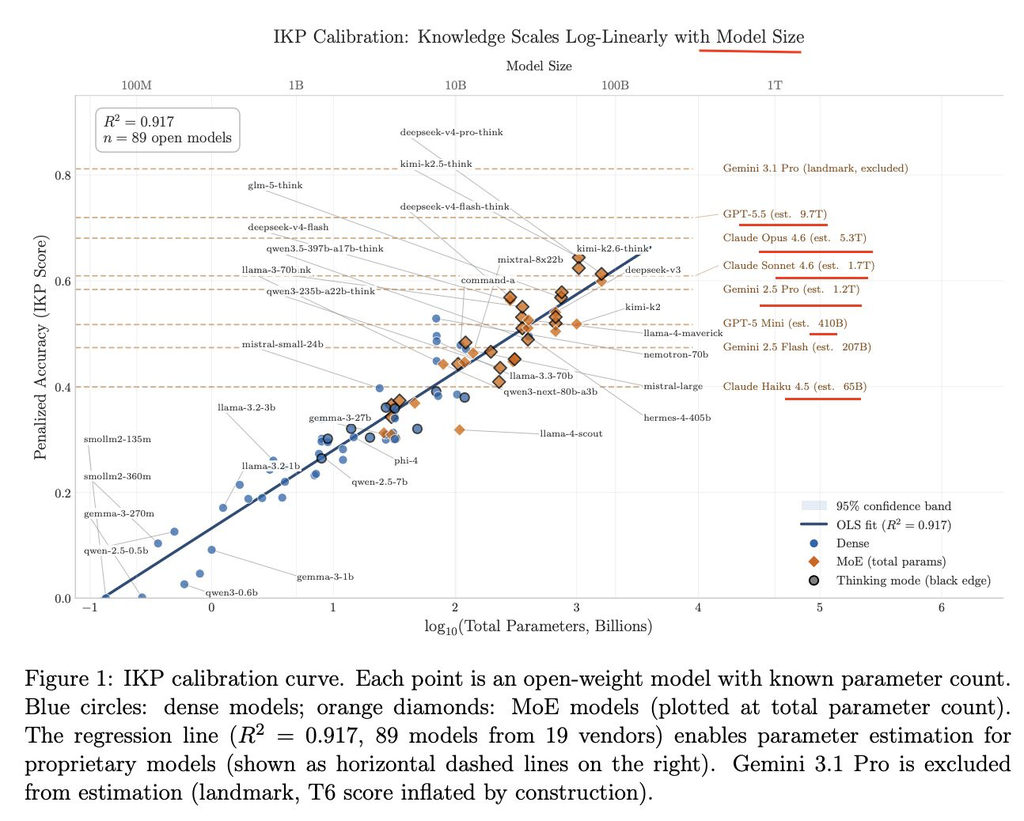

01Bienvenidos 02¿Por qué esta materia? 03Logística 04Fundamento de AI 05Taxinomia de Problemas 06Modelos Fundacionales 07Datos 08Ecosistema Actual 09Cierre y anexo

08

Ecosistema Actual

Ecosistema Actual

## Modelos de propósito general

### OpenAI — GPT-5.2

Cerrado, por API. El ecosistema de herramientas más grande.

### Google DeepMind — Gemini 3.6 Flash

La variante Flash cambia potencia por latencia y costo.

### Anthropic — Claude 4

Familia escalonada: Opus para lo difícil, Sonnet para el resto.

### Meta — Llama 4 Maverick y Scout

Pesos abiertos: se despliega en infraestructura propia.

### DeepSeek — V4 Pro y V4 Flash

Compite por costo por token, no por el primer puesto.

### Moonshot AI — Kimi K3

Contexto largo y uso de herramientas en varios pasos.

### Alibaba — Qwen3.7-Max

Familia amplia, con versiones abiertas y foco no estadounidense.

01Bienvenidos 02¿Por qué esta materia? 03Logística 04Fundamento de AI 05Taxinomia de Problemas 06Modelos Fundacionales 07Datos 08Ecosistema Actual 09Cierre y anexo

09

Cierre y anexo

Cierre y anexo

## Conclusiones Clave

Conclusiones clave — Lo que debes llevarte de esta sesión

1

La IA aprende de datos, objetivos y retroalimentación; no funciona como un conjunto fijo de reglas escritas a mano.

2

Los foundation models cambiaron las reglas del juego: un modelo entrenado a escala puede adaptarse a texto, código, imágenes y tareas de producto.

3

La escala importa, pero también la alineación, la seguridad, la evaluación y el control sobre los datos.

4

Los agentes y la multimodalidad amplían las capacidades de los sistemas. Los equipos deben diseñar permisos, trazabilidad y mecanismos de supervisión.

Preguntas: este es el momento para conectar los conceptos con problemas concretos de Ingeniería de Software.

Anexo

Cierre y anexo

## Modelos Discriminativos vs Generativos

La distinción entre modelos discriminativos y generativos ayuda a elegir el enfoque técnico adecuado. Los modelos discriminativos dibujan fronteras de decisión para clasificar datos existentes. Los generativos aprenden una distribución y producen nuevas instancias.

### Discriminativo

Qué aprenden: p(y|x), la probabilidad de una etiqueta dado un input.

Qué responden

- ¿A qué clase pertenece este dato?

Ejemplos: Clasificación de tickets · detección de fraude · priorización de alertas.

### Generativo

Qué aprenden: p(x) o p(x,y), la distribución completa de los datos.

Qué responden

- ¿Cómo se vería una instancia compatible con esta distribución?

Ejemplos: Generación de código de prueba · documentación · GPT-4 · Stable Diffusion.

Conexión moderna: los LLMs son generativos, pero pueden asistir en tareas discriminativas mediante prompting, herramientas y validación externa.

Cierre y anexo

## El Desafío del Mundo Real

De la teoría a la práctica

### Entorno Ideal (Laboratorio)

Totalmente observable, determinista, episódico, estático, discreto, conocido y de agente único.

Ejemplo: Resolver un Sudoku o jugar al Tres en Raya (Tic-Tac-Toe). Resultado: Problemas resueltos hace décadas con algoritmos simples.

### Entorno Real (El campo de batalla)

Parcialmente observable, estocástico, secuencial, dinámico, continuo, multiagente y desconocido.

Ejemplo: Conducción autónoma en una ciudad con tráfico impredecible o robótica de rescate. Resultado: Requiere agentes que aprenden, planifican con incertidumbre y optimizan utilidades.

¿Por qué ganarle al campeón mundial de ajedrez (1997) fue 'fácil' comparado con lograr que un coche se conduzca solo bajo la lluvia? El entorno lo explica todo.

Cierre y anexo

## El futuro: agentes autónomos e IA multimodal

### Agentes autónomos

Los LLMs evolucionan de herramientas de pregunta-respuesta a agentes capaces de planificar, usar APIs, navegar, consultar repositorios, ejecutar código y completar tareas de varios pasos. Frameworks como LangGraph, AutoGen u OpenAI Agents permiten orquestar agentes que colaboran para investigar, operar un flujo de trabajo, asistir a soporte o coordinar herramientas de desarrollo.

### IA multimodal

Los modelos procesan y generan texto, imágenes, audio, video y código dentro de una misma experiencia. Modelos multimodales: texto + visión + audio en tiempo real. Generación de video: prototipos, demostraciones y contenido audiovisual. Implicaciones: análisis de interfaces, accesibilidad, educación inmersiva, soporte técnico y automatización de tareas con herramientas.

### Control y seguridad

La autonomía requiere permisos acotados, auditoría de acciones, evaluación y capacidad de detener el sistema.

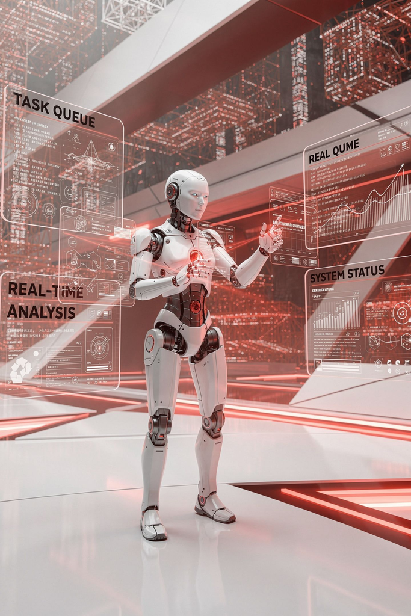

Cierre y anexo

## Tipos de Agentes en IA

De la reacción simple al aprendizaje autónomo

Tipo de AgenteBase de DecisiónCapacidad ClaveLimitación Principal

Reactivo SimplePercepción actual (Condición ➔ Acción)Rápido y directoSin memoria; falla si no puede ver todo el entorno en el momento.

Basado en ModelosPercepción + Estado Interno (Memoria)Entiende el contexto continuo y recuerda lo que ya no veNo planifica hacia el futuro; solo reacciona a la situación actual.

Basado en ObjetivosEstado Interno + Metas a futuroPlanifica secuencias de acciones para lograr un resultadoNo distingue si un camino es eficiente o costoso, solo si llega a la meta.

Basado en UtilidadMetas + Función de "Felicidad/Eficiencia"Optimiza; evalúa y elige la mejor opción posibleNo sabe adaptarse de forma autónoma a entornos o reglas totalmente nuevas.

Que AprendeUtilidad + Evaluación (Crítico) y ExploraciónEvoluciona, corrige errores pasados y se adapta a lo desconocidoMayor complejidad de diseño y requiere procesamiento de entrenamiento.

Cierre y anexo

## Dimensiones del Entorno

Simple (Laboratorio) vs. Complejo (Mundo Real)

DimensiónEntorno Simple (Laboratorio)Entorno Complejo (Mundo Real)Implicancia para la IA

ObservabilidadTotalmente Observable: Sensores captan todo. (Ej: Ajedrez, ves todo el tablero)Parcialmente Observable: Información oculta. (Ej: Póker, cartas ocultas; conducir con niebla)Debe decidir asumiendo la información que le falta.

CertezaDeterminista: Resultado exacto garantizado. (Ej: Cubo Rubik, las piezas van donde las movés)Estocástico: Azar o probabilidad. (Ej: Frenar sobre asfalto mojado)Requiere manejar el riesgo y la incertidumbre.

Impacto TemporalEpisódico: Decisiones aisladas. (Ej: IA que clasifica fotos de gatos)Secuencial: Acciones afectan el futuro. (Ej: Inversiones financieras a largo plazo)Obliga a planificar a futuro y prever consecuencias.

EstabilidadEstático: El entorno espera. (Ej: Resolver un Sudoku en papel)Dinámico: Cambia mientras "piensa". (Ej: Conducir en el tráfico del centro)La velocidad de procesamiento es cuestión de supervivencia.

ValoresDiscreto: Estados y opciones finitas. (Ej: Casillas y turnos de las Damas)Continuo: Variables fluidas e infinitas. (Ej: Ángulos, viento y fuerza al volar un dron)Aumenta drásticamente la cantidad de cálculos.

ParticipantesAgente Único: Opera solo. (Ej: IA resolviendo un laberinto)Multiagente: Otros actores interactúan. (Ej: Robots jugando fútbol, vehículos cooperando)Debe predecir el comportamiento ajeno.

ReglasConocido: Sabe cómo funciona todo. (Ej: Solitario, las reglas vienen programadas)Desconocido: Ignora las reglas. (Ej: Robot explorando terreno en Marte)Exige explorar y aprender mediante ensayo y error.

Diapositiva de reserva

Girá el teléfono para ver las diapositivas